# Exercise 1: Getting started with data science and machine learning

Jacqueline Liu

Assignments for the course focus on practical aspects of the concepts covered in the lectures. Assignments are based on the material covered in James et al. Normally you will start working on the assignments after class. **Think about the assignments as the most practical and also the best way to learn machine learning!**

# Introduction to RMarkdown

Before we dive into our first exercise, let’s become a bit more familiar with the programming tools used in this course.

We will write our annotated R code using [Markdown](http://rmarkdown.rstudio.com).

You can run each chunk of code one by one, by highlighting the code and clicking `Run` (or pressing `Ctrl + Enter` in Windows or `command + enter` in OS X). You can see the output of the code in the console right below, inside the RStudio window.

Alternatively, you can generate (or **knit**) an html document with all the code, comment, and output in the entire `.Rmd` file by clicking on `Knit HTML`. The Notebook contains HTML output and embedded code. You can generate it by clicking `Preview` after running all the code chunks.

You can also embed plots and graphics, for example:

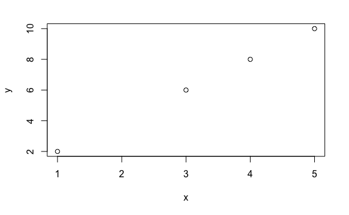

```r
x <- c(1, 3, 4, 5)
y <- c(2, 6, 8, 10)
plot(x, y)
```

If you run the chunk of code, the plot will be generated on the panel on the bottom right corner. If instead you knit the entire file, the plot will appear after you view the html document.

Using R + Markdown has several advantages: it leaves an “audit trail” of your work, including documentation explaining the steps you made. This is helpful to not only keep your own progress organised, but also make your work reproducible and more transparent. You can easily correct errors (just fix them and run the script again), and after you have finished, you can generate a PDF or HTML version of your work.

We will be exploring R through R Markdown over the next weeks. For more details and documentation see http://rmarkdown.rstudio.com. R (or Python) Notebooks are also the only acceptable format for your assignments!

# Make sure R and RStudio are installed

Follow the instructions in the class material and install R and RStudio. If you feel more comfortable using the basic R terminal, skip the step of installing RStudio and the corresponding chunk.

Now run the following code to make sure that you have the current version of R.

```r
version$version.string
```

```
[1] "R version 3.5.2 (2018-12-20)"
```

This chunk should return something like `R version 3.5.1 (2018-07-02)`.

```r
rstudioapi::versionInfo()$version
```

```
[1] ‘1.1.463’
```

This chunk should print `1.1.423`.

If they do not, then try to get as close to the current versions as possible!

# Basic regression operations in R

For this we will use the automobile dataset from the James et. al. text. This can be found in the **ISLR** package in R.

Start by loading this package:

```r
install.packages("ISLR")
```

```r
library(ISLR)
```

Now we can regress miles-per-gallon on the weight of the vehicle and the number of cylinders.

```r
data(Auto)
with(Auto, lm(mpg ~ weight + cylinders))
```

```
Call:
lm(formula = mpg ~ weight + cylinders)

Coefficients:
(Intercept)       weight    cylinders
  46.292310    -0.006347    -0.721378
```

Why did we need the `with()` wrapper?

The `with()` wrapper applies the `lm()` function, which regresses miles-per-gallon (`mpg`) with `weight` and `cylinders`, to the dataset `Auto`.

The data is not loaded into an object. The `with()` wrapper allows us to apply the function on the dataset.

# Exercise

## 1. Working with a sample dataset

This exercise relates to the `College` data set, which can be found in the file `College.csv` on the website for the main course textbook (James et al 2013) http://www-bcf.usc.edu/~gareth/ISL/data.html. It contains a number of variables for 777 different universities and colleges in the US.

The variables are:  
* `Private` : Public/private indicator  
* `Apps` : Number of applications received  
* `Accept` : Number of applicants accepted  
* `Enroll` : Number of new students enrolled  
* `Top10perc` : New students from top 10% of high school class * `Top25perc` : New students from top 25% of high school class  
* `F.Undergrad` : Number of full-time undergraduates * `P.Undergrad` : Number of part-time undergraduates  
* `Outstate` : Out-of-state tuition  
* `Room.Board` : Room and board costs  
* `Books` : Estimated book costs  
* `Personal` : Estimated personal spending  
* `PhD` : Percent of faculty with Ph.D.’s  
* `Terminal` : Percent of faculty with terminal degree  
* `S.F.Ratio` : Student/faculty ratio * `perc.alumni` : Percent of alumni who donate  
* `Expend` : Instructional expenditure per student  
* `Grad.Rate` : Graduation rate

Before reading the data into R, it can be viewed in Excel or a text editor, if you find that convenient.

### 1.1 Load the data

Use the `read.csv()` function to read the data into `R`. Call the loaded data `college`. Make sure that you have the directory set to the correct location for the data. You can load this in R directly from the website, using:

```r
college <- read.csv("http://www-bcf.usc.edu/~gareth/ISL/College.csv")
```

### 1.2 View the data

Look at the data using the `View()` function. You should notice that the first column is just the name of each university. We don’t really want R to treat this as data. However, it may be handy to have these names for later. Try the following commands:

```r
rownames(college) <- college[, 1]
View(college)
```

You should see that there is now a `row.names` column with the name of each university recorded. This means that R has given each row a name corresponding to the appropriate university. R will not try to perform calculations on the row names. However, we still need to eliminate the first column in the data where the names are stored. Try

```r
college <- college[, -1]
View(college)
```

### 1.3 Try some operations

1. Use the `summary()` function to produce a numerical summary of the variables in the data set.

```r
summary(college)
```

[output not shown]

2. Use the `pairs()` function to produce a scatterplot matrix of the first ten columns or variables of the data. Recall that you can reference the first ten columns of a matrix `A` using `A[,1:10]`.

[figure not shown]

```r
pairs(college[,1:10])
```

3. Use the `plot()` function to produce side-by-side boxplots of `Outstate` versus `Private`.

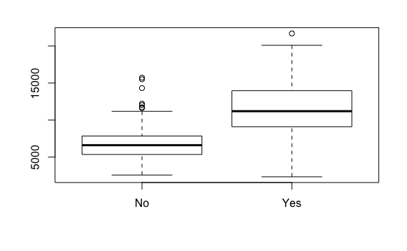

```r
plot(college$Private, college$Outstate)
```

4. Create a new qualitative variable, called `Elite`, by *binning* the `Top10perc` variable. We are going to divide universities into two groups based on whether or not the proportion of students coming from the top 10% of their high school classes exceeds 50%.

```r
Elite <- rep("No", nrow(college))
Elite[college$Top10perc > 50] <- "Yes"
Elite <- as.factor(Elite)
college <- data.frame(college, Elite)
```

Use the `summary()` function to see how many elite universities there are. Now use the `plot()` function to produce side-by-side boxplots of `Outstate` versus `Elite`.

```r
summary(college$Elite)
```

```
 No Yes
699  78
```

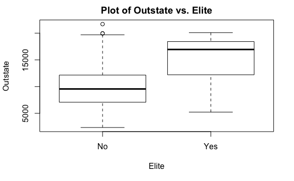

```r
plot(college$Elite, college$Outstate, main = "Plot of Outstate vs. Elite", xlab = "Elite", ylab = "Outstate")
```

Continue exploring the data, and provide a brief summary of what you discover.

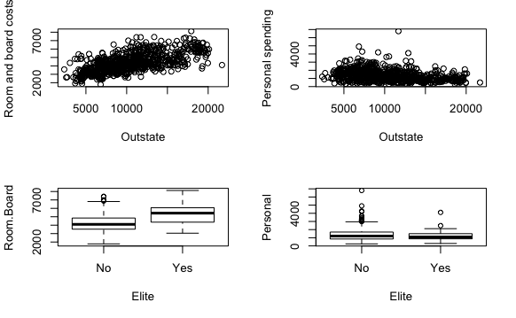

Out-of-state tuition fees have a positive relationship with room and board costs. However, personal spending seems comparable across individuals regardless of whether they attend an elite college with higher tuition fees.

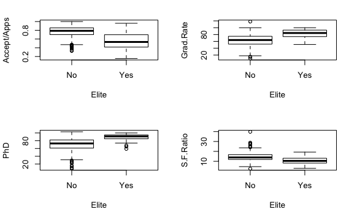

Elite colleges have lower acceptance rates and higher graduation rates than non-elite colleges. Elite colleges also have a higher percentage of faculty with PhDs and a lower student-faculty ratio compared to non-elite colleges.

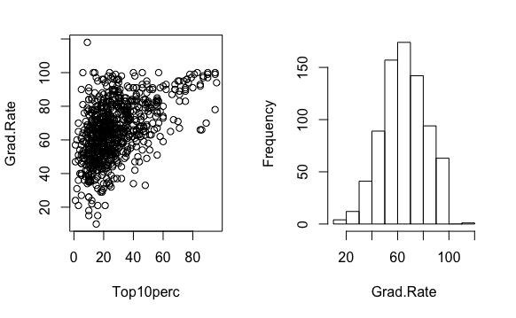

However, colleges with the highest number of students from the top 10% of their high school class do not necessarily have the highest grduation rate. In addition, a closer inspection of the graduation rate also revealed a rate of more than 100, which is likely to be erroneous.

### 2. Working with the automotive dataset

This exercise involves the `Auto` data set available as `Auto.csv` from the website for the main course textbook James et al. http://www-bcf.usc.edu/~gareth/ISL/data.html. Make sure that the missing values have been removed from the data. You should load that dataset as the first step of the exercise.

```r
Auto <- read.csv("http://www-bcf.usc.edu/~gareth/ISL/Auto.csv",
                 header = TRUE, na.strings = "?")
Auto <- na.omit(Auto)
dim(Auto)
```

```
[1] 392   9
```

```r
summary(Auto)
```

```
      mpg          cylinders      displacement     horsepower
 Min.   : 9.00   Min.   :3.000   Min.   : 68.0   Min.   : 46.0
 1st Qu.:17.00   1st Qu.:4.000   1st Qu.:105.0   1st Qu.: 75.0
 Median :22.75   Median :4.000   Median :151.0   Median : 93.5
 Mean   :23.45   Mean   :5.472   Mean   :194.4   Mean   :104.5
 3rd Qu.:29.00   3rd Qu.:8.000   3rd Qu.:275.8   3rd Qu.:126.0
 Max.   :46.60   Max.   :8.000   Max.   :455.0   Max.   :230.0

     weight      acceleration        year           origin
 Min.   :1613   Min.   : 8.00   Min.   :70.00   Min.   :1.000
 1st Qu.:2225   1st Qu.:13.78   1st Qu.:73.00   1st Qu.:1.000
 Median :2804   Median :15.50   Median :76.00   Median :1.000
 Mean   :2978   Mean   :15.54   Mean   :75.98   Mean   :1.577
 3rd Qu.:3615   3rd Qu.:17.02   3rd Qu.:79.00   3rd Qu.:2.000
 Max.   :5140   Max.   :24.80   Max.   :82.00   Max.   :3.000

                 name
 amc matador       :  5
 ford pinto        :  5
 toyota corolla    :  5
 amc gremlin       :  4
 amc hornet        :  4
 chevrolet chevette:  4
 (Other)           :365
```

1. Which of the predictors are quantitative, and which are qualitative?

```r
str(Auto)
```

```
'data.frame':   392 obs. of  9 variables:
 $ mpg         : num  18 15 18 16 17 15 14 14 14 15 ...
 $ cylinders   : int  8 8 8 8 8 8 8 8 8 8 ...
 $ displacement: num  307 350 318 304 302 429 454 440 455 390 ...
 $ horsepower  : int  130 165 150 150 140 198 220 215 225 190 ...
 $ weight      : int  3504 3693 3436 3433 3449 4341 4354 4312 4425 3850 ...
 $ acceleration: num  12 11.5 11 12 10.5 10 9 8.5 10 8.5 ...
 $ year        : int  70 70 70 70 70 70 70 70 70 70 ...
 $ origin      : int  1 1 1 1 1 1 1 1 1 1 ...
 $ name        : Factor w/ 304 levels "amc ambassador brougham",..: 49 36 231 14 161 141 54 223 241 2 ...
 - attr(*, "na.action")= 'omit' Named int  33 127 331 337 355
  ..- attr(*, "names")= chr  "33" "127" "331" "337" ...
```

- Quantitative predictors: mpg, cylinders, displacement, horsepower, weight, acceleration, year
- Qualitative predictors: origin, name
2. What is the *range* of each quantitative predictor? You can answer this using the `range()` function.

```r
sapply(Auto[,1:7], range)
```

```
      mpg cylinders displacement horsepower weight acceleration year
[1,]  9.0         3           68         46   1613          8.0   70
[2,] 46.6         8          455        230   5140         24.8   82
```

3. What is the mean and standard deviation of each quantitative predictor? **Mean**

```r
sapply(Auto[,1:7], mean)
```

```
         mpg    cylinders displacement   horsepower       weight
   23.445918     5.471939   194.411990   104.469388  2977.584184
acceleration         year
   15.541327    75.979592
```

**Standard deviation**

```r
sapply(Auto[,1:7], sd)
```

```
         mpg    cylinders displacement   horsepower       weight
    7.805007     1.705783   104.644004    38.491160   849.402560
acceleration         year
    2.758864     3.683737
```

4. Now remove the 10th through 85th observations. What is the range, mean, and standard deviation of each predictor in the subset of the data that remains?

```r
subAuto = Auto[-(10:85),]
summary(subAuto)
```

```
      mpg          cylinders      displacement     horsepower
 Min.   :11.00   Min.   :3.000   Min.   : 68.0   Min.   : 46.0
 1st Qu.:18.00   1st Qu.:4.000   1st Qu.:100.2   1st Qu.: 75.0
 Median :23.95   Median :4.000   Median :145.5   Median : 90.0
 Mean   :24.40   Mean   :5.373   Mean   :187.2   Mean   :100.7
 3rd Qu.:30.55   3rd Qu.:6.000   3rd Qu.:250.0   3rd Qu.:115.0
 Max.   :46.60   Max.   :8.000   Max.   :455.0   Max.   :230.0

     weight      acceleration        year           origin
 Min.   :1649   Min.   : 8.50   Min.   :70.00   Min.   :1.000
 1st Qu.:2214   1st Qu.:14.00   1st Qu.:75.00   1st Qu.:1.000
 Median :2792   Median :15.50   Median :77.00   Median :1.000
 Mean   :2936   Mean   :15.73   Mean   :77.15   Mean   :1.601
 3rd Qu.:3508   3rd Qu.:17.30   3rd Qu.:80.00   3rd Qu.:2.000
 Max.   :4997   Max.   :24.80   Max.   :82.00   Max.   :3.000

                        name
 ford pinto               :  5
 toyota corolla           :  5
 amc matador              :  4
 chevrolet chevette       :  4
 amc hornet               :  3
 chevrolet caprice classic:  3
 (Other)                  :292
```

```r
View(subAuto)
```

**Range**

```
      mpg cylinders displacement horsepower weight acceleration year
[1,] 11.0         3           68         46   1649          8.5   70
[2,] 46.6         8          455        230   4997         24.8   82
```

**Mean**

```
         mpg    cylinders displacement   horsepower       weight
   24.404430     5.373418   187.240506   100.721519  2935.971519
acceleration         year
   15.726899    77.145570
```

**Standard deviation**

```
         mpg    cylinders displacement   horsepower       weight
    7.867283     1.654179    99.678367    35.708853   811.300208
acceleration         year
    2.693721     3.106217
```

5. Using the full data set, investigate the predictors graphically, using scatterplots or other tools of your choice. Create some plots highlighting the relationships among the predictors. Comment on your findings.

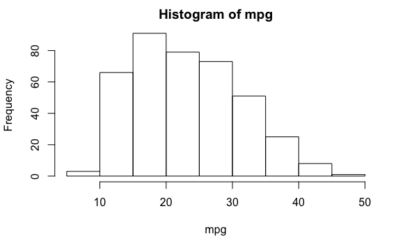

**Relationship of predictors with `mpg`**

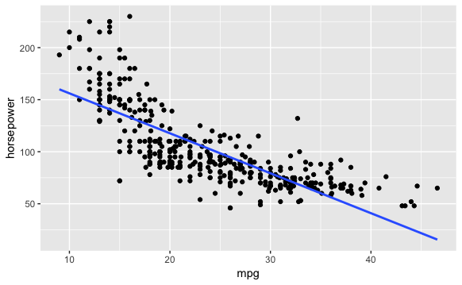

```r
library(ggplot2)
with(Auto, ggplot(Auto, aes(x = mpg, y = horsepower))
     + geom_point()
     + geom_smooth(method=lm, se=FALSE))
```

```r
par(mfrow = c(2,2))
plot(Auto$displacement, Auto$mpg, xlab = "displacement", ylab = "mpg")
plot(Auto$horsepower, Auto$mpg, xlab = "horsepower", ylab = "mpg")
plot(Auto$weight, Auto$mpg, xlab = "weight", ylab = "mpg")
plot(Auto$acceleration, Auto$mpg, xlab = "acceleration", ylab = "mpg")
```

[output not shown]

```r
par(mfrow = c(1,2))
boxplot(Auto$mpg ~ Auto$cylinders, xlab = "cylinders", ylab = "mpg")
boxplot(Auto$mpg ~ Auto$year, xlab = "year", ylab = "mpg")
```

[output not shown]

Overall, predictors appear to have a non-linear relationship with `mpg`. Higher levels of displacement, horsepower and weight seem correlated with lower gas mileage/ fuel efficiency. While higher acceleration may or may not correspond to higher gas mileage/ fuel efficiency. The number of cylinders and `mpg` seems to have diminishing marginal effects on `mpg`. Older cars are also likely to be less efficient.

**Relationships between predictors**

```r
par(mfrow = c(2,2))
plot(Auto$cylinders, Auto$displacement)
plot(Auto$displacement, Auto$horsepower)
plot(Auto$cylinders, Auto$weight)
plot(Auto$acceleration, Auto$horsepower)
```

[output not shown]

Some of the predictors appear to be correlated with each other. Number of cylinders is positively correlated with displacement as the measurement of engine displacement depends on the number of cylinders. Number of cylinders also exhibits a positive relationship with weight. Displacement may also generally be positively related with horsepower, while acceleration seems to be negatively related to horsepower.

6. Suppose that we wish to predict gas mileage (`mpg`) on the basis of the other variables. Do your plots suggest that any of the other variables might be useful in predicting `mpg`? Justify your answer.

As most of the predictors except for `name` and `origin` exhibit some relationship with `mpg`, they could be used to predict gas mileage. However, we should avoid including too many of these predictors in a model (e.g. multiple linear regression) as several predictors may be correlated with each other resulting in multicollinearity, which may affect the efficiency of the model. Other model designs should be considered to control for correlations between predictors. As predictors seem to have a non-linear relationship with `mpg`, this could indicate the need to use the logarithm of `mpg` as the dependent variable in our models.

### Further materials

- [Data Camp R tutorials](https://www.datacamp.com/courses/free-introduction-to-r)
- [Data Camp R Markdown tutorials](https://www.datacamp.com/courses/reporting-with-r-markdown). You can complete the free first chapter.